# multivariate_test.Rに対応したR Notebook

## 第9章の内容

### データの準備

まずは第8章までと同じデータを読み込む

```r
###For chapter 09
####Preparation#####
library(vegan)
phyto_metadata <- readRDS("phyto_metadata.obj")
species_ryuko_data <- readRDS("phyto_ryuko_data.obj")
metadata_ecoplate <- readRDS("metadata_ecopl.obj")
summary_ecoplate <- readRDS("summary_ecopl.obj")
species_richness <- apply(species_ryuko_data > 0, 1, sum)
total_abundance <- apply(species_ryuko_data, 1, sum)

substrate_name <- c("Pyruvic-Acid-Methyl-Ester", "Tween-40", "Tween-80","alpha-Cyclodextrin", "Glycogen", "D-Cellobiose","alpha-D-Lactose", "beta-Methyl-D-Glucoside", "D-Xylose", "i-Erythritol", "D-Mannitol","N-Acetyl-D-Glucosamine", "D-Glucosaminic-Acid", "Glucose-1-Phosphate","alpha-Glycerol-Phosphate","D-Galactonic-Acid-gamma-Lactone", "D-Galacturonic-Acid", "2-Hydroxy-Benzoic-Acid", "4-Hydroxy-Benzoic-Acid", "gamma-Hydroxybutyric-Acid", "Itaconic-Acid", "alpha-Ketobutyric-Acid", "D-Malic-Acid", "L-Arginine", "L-Asparagine", "L-Phenylalanine", "L-Serine", "L-Threonine", "Glycyl-L-Glutamic-Acid", "Phenylethyl-amine", "Putrescine")

substrate_jpn <- c("Pyruvic-Acid-Methyl-Ester", "Tween-40", "Tween-80","alpha-Cyclodextrin", "Glycogen", "D-Cellobiose","alpha-D-Lactose", "beta-Methyl-D-Glucoside", "D-Xylose", "i-Erythritol", "D-Mannitol","N-Acetyl-D-Glucosamine", "D-Glucosaminic-Acid", "Glucose-1-Phosphate","alpha-Glycerol-Phosphate","D-Galactonic-Acid-gamma-Lactone", "D-Galacturonic-Acid", "2-Hydroxy-Benzoic-Acid", "4-Hydroxy-Benzoic-Acid", "gamma-Aminobutyric-acid", "Itaconic-Acid", "alpha-Ketobutyric-Acid", "D-Malic-Acid", "L-Arginine", "L-Asparagine", "L-Phenylalanine", "L-Serine", "L-Threonine", "Glycyl-L-Glutamic-Acid", "Phenylethyl-amine", "Putrescine")
```

### 9.1 一般線形モデルの多変量への拡張１：分散分析的状況

#### 9.1.1 主座標分析による可視化の復習

```r
####PCoA plot for ecoplate####
#With Bray-Curtis
PCoA_ecoplate_BC <- summary(capscale(summary_ecoplate ~ 1, distance = "bray"))
PCoA_ecoplate_BC
```

```
Call:
capscale(formula = summary_ecoplate ~ 1, distance = "bray")

Partitioning of squared Bray distance:
              Inertia Proportion
Total          0.2013          1
Unconstrained  0.2013          1

Eigenvalues, and their contribution to the squared Bray distance

Importance of components:
                         MDS1    MDS2    MDS3    MDS4
Eigenvalue            0.04957 0.02486 0.02252 0.02129
Proportion Explained  0.24622 0.12351 0.11186 0.10578
Cumulative Proportion 0.24622 0.36974 0.48159 0.58737
                         MDS5    MDS6    MDS7
Eigenvalue            0.01602 0.01508 0.01234
Proportion Explained  0.07959 0.07493 0.06129
Cumulative Proportion 0.66696 0.74189 0.80318
                          MDS8    MDS9    MDS10
Eigenvalue            0.009562 0.00738 0.006229
Proportion Explained  0.047497 0.03666 0.030940
Cumulative Proportion 0.850680 0.88734 0.918279
                         MDS11    MDS12    MDS13
Eigenvalue            0.004921 0.004402 0.003659
Proportion Explained  0.024444 0.021867 0.018174
Cumulative Proportion 0.942723 0.964590 0.982764
                         MDS14    MDS15
Eigenvalue            0.002326 0.001144
Proportion Explained  0.011552 0.005684
Cumulative Proportion 0.994316 1.000000

Scaling 2 for species and site scores
* Species are scaled proportional to eigenvalues
* Sites are unscaled: weighted dispersion equal on all dimensions
* General scaling constant of scores:  1.463668


Species scores

```

[output cut: 103 more lines]

[output not shown]

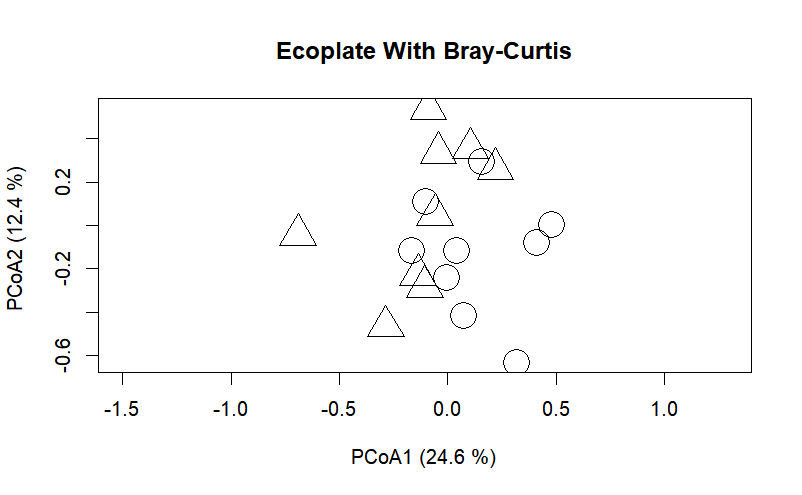

```r
PCoA1_ecoplate_BC <- PCoA_ecoplate_BC$sites[,1]
PCoA2_ecoplate_BC <- PCoA_ecoplate_BC$sites[,2]
plot(
  PCoA2_ecoplate_BC ~ PCoA1_ecoplate_BC,
  cex = 3, pch = as.numeric(as.factor(metadata_ecoplate$treatment)),
  xlab = "PCoA1 (24.6 %)", ylab = "PCoA2 (12.4 %) ",
  asp = 1,
  main = "Ecoplate With Bray-Curtis"
)
```

#### 9.1.2 分散分析的取り扱い

F値の計算をしてみる

```r
####Calculate F-values####
#ブレイ・カーティス距離の計算
ecoplate_BC.d <- vegdist(summary_ecoplate, method = "bray")
#PERMANOVAによるF値の計算
ecoplate_BC_F <- adonis(ecoplate_BC.d ~ metadata_ecoplate$treatment)$aov.tab$F.Model[1]
```

```
'adonis' will be deprecated: use 'adonis2' instead
```

```r
#この観測データに基づくF値
ecoplate_BC_F
```

```
[1] 2.757547
```

#### 9.1.3 ランダム並び替え検定の仕組み

図9.3用のコード

```
'adonis' will be deprecated: use 'adonis2' instead
```

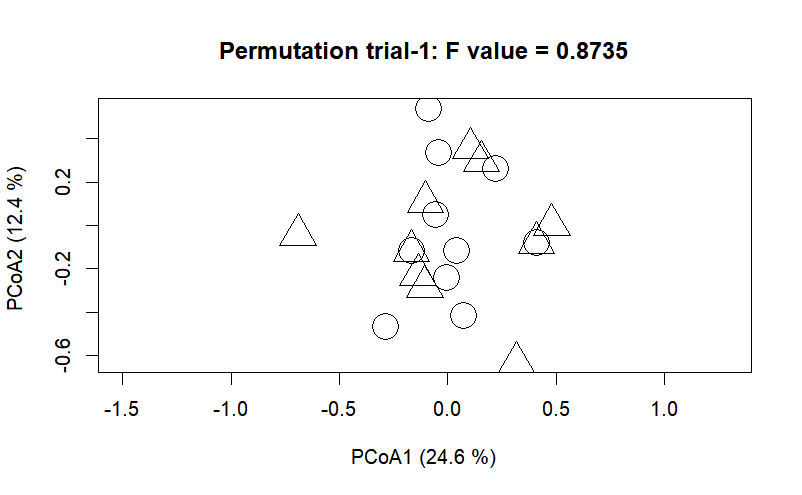

```
'adonis' will be deprecated: use 'adonis2' instead
```

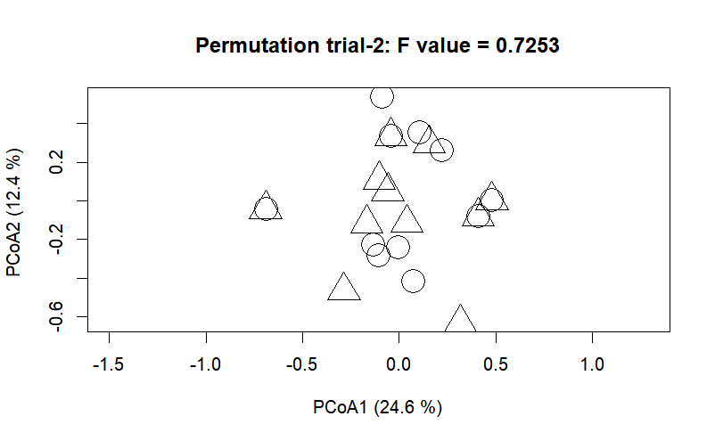

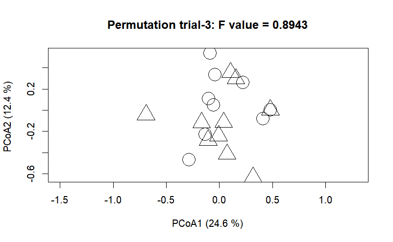

```r
####Example of permutation####
set.seed(1235) #fix the random seed　疑似乱数列の初期化
leng <- length(metadata_ecoplate$treatment)
for(i in 1:3) {
  perm_treatment <- sample(metadata_ecoplate$treatment, leng, replace = FALSE) #shuffling the index
  F_perm <- round(adonis(ecoplate_BC.d ~ perm_treatment)$aov.tab$F.Model[1],4)
  plot(
   PCoA2_ecoplate_BC ~ PCoA1_ecoplate_BC,
   cex = 3, pch = as.numeric(as.factor(perm_treatment)),
   xlab = "PCoA1 (24.6 %)", ylab = "PCoA2 (12.4 %) ",
   asp = 1,
   main = paste("Permutation trial-", i, ": F value = ", F_perm, sep="")
  )
}
```

図9.4用のコード

ランダム並び替えから得られたF値の頻度(度数)分布

```r
####1000 permutations
#999回ランダム並び替えを行なう
test_for_Fperm <- adonis(ecoplate_BC.d ~ metadata_ecoplate$treatment, perm = 999)
```

```
'adonis' will be deprecated: use 'adonis2' instead
```

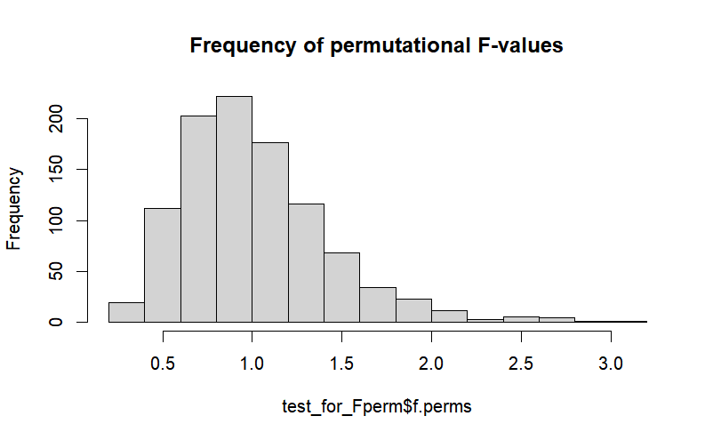

```r
#ランダム並び替えで得られたF値についてヒストグラムを描く
hist(test_for_Fperm$f.perms, main = "Frequency of permutational F-values")
```

```r
#ランダム並び替えで得られたF値のうち、観測データから得られたF値以上になった回数
sum(test_for_Fperm$f.perms >= ecoplate_BC_F) # fraction with which permutational F is equal or greater than the observed F value.
```

```
[1] 3
```

```r
#P値の計算
(sum(test_for_Fperm$f.perms >= ecoplate_BC_F) + 1)/(999 + 1)
```

```
[1] 0.004
```

#### 9.1.4 Permutational MANOVA (PERMANOVA)

```r
####PERMANOVA for ecoplate data####
#ブレイ・カーティス距離を計算
ecoplate_BC.d <- vegdist(summary_ecoplate, method = "bray") #Bray-Curtis
#エコプレートデータに対するPERMANOVAの実行
ecoplate_BC_permanova <- adonis(ecoplate_BC.d ~ metadata_ecoplate$treatment, perm = 999)
```

```
'adonis' will be deprecated: use 'adonis2' instead
```

```r
#PERMANOVAの結果のうち分散分析表のみ表示
ecoplate_BC_permanova$aov.tab
```

```
Permutation: free
Number of permutations: 999

Terms added sequentially (first to last)

                            Df SumsOfSqs  MeanSqs
metadata_ecoplate$treatment  1  0.022226 0.022226
Residuals                   22  0.177320 0.008060
Total                       23  0.199546
                            F.Model      R2 Pr(>F)
metadata_ecoplate$treatment  2.7576 0.11138  0.001
Residuals                           0.88862
Total                               1.00000

metadata_ecoplate$treatment ***
Residuals
Total
---
Signif. codes:
0 ‘***’ 0.001 ‘**’ 0.01 ‘*’ 0.05 ‘.’ 0.1 ‘ ’ 1
```

#### 9.1.5 「分布に差がある」とは何か

PERMDISPで散布度(=水準内分散)の不均一性を評価(帰無仮説は水準内分散が均一)

```r
####PERMDISP for ecoplate data####
#ブレイ・カーティス距離を計算
ecoplate_BC.d <- vegdist(summary_ecoplate, method = "bray") #Bray-Curtis
#PERMDISPによって水準内分散を評価
ecoplate_BC_var <- betadisper(ecoplate_BC.d, metadata_ecoplate$treatment)
#ランダム並び替え検定によって水準内分散の不均一性を評価
permutest(ecoplate_BC_var, perm = 999)
```

```
Permutation test for homogeneity of
multivariate dispersions
Permutation: free
Number of permutations: 999

Response: Distances
          Df    Sum Sq    Mean Sq      F N.Perm
Groups     1 0.0000391 0.00003908 0.0984    999
Residuals 22 0.0087390 0.00039723
          Pr(>F)
Groups     0.766
Residuals
```

水準ごとの水準内分散は可視化できる(すでに検定をしているので可視化しても差がない雰囲気が感じられるはず)

betadisper関数の出力を格納したオブジェクトecoplate_BC_varには、distanceという要素で、各データと水準の分布中心とのユークリッド距離が格納されている。これをメタデータmetadata_ecoplateに格納されている処理区情報(treatment)を説明要因として箱ひげ図と散布図を重ねて描く

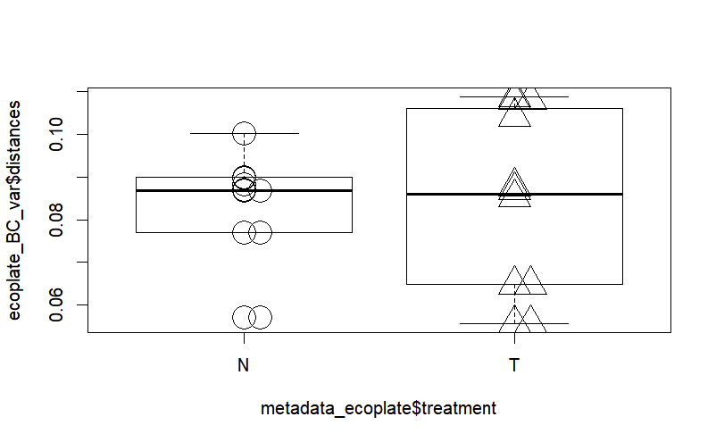

```r
#Visualization
#水準ごとに、分布中心と各データとの距離を箱ひげ図で描写
boxplot(
  ecoplate_BC_var$distances ~ metadata_ecoplate$treatment, #「距離 ~ 処理」というモデル式
  outline = FALSE,
  col = "white"
)
#水準ごとに、分布中心と各データとの距離を散布図で描写
stripchart(
  ecoplate_BC_var$distances ~ metadata_ecoplate$treatment, #「距離 ~ 処理」というモデル式
  method = "stack",
  pch = c(1,2),
  cex = 3,
  vertical = TRUE,
  add = TRUE
)
```

#### 9.1.6 PERMDISP自体にも意味がある

```r
####PERMDISP for phytoplankton####
#植物プランクトンデータに対する3月vs5月での水準内分散の比較
#ブレイ・カーティス距離を計算：3月と5月のデータのみ使用
ryuko_BC.d <- vegdist(species_ryuko_data[c(1,2,13,14,15),], method = "bray") #Bray-Curtis
#水準内分散の比較を実行
ryuko_BC_var <- betadisper(ryuko_BC.d, phyto_metadata$month[c(1,2,13,14,15)])
#ランダム並び替え検定
permutest(ryuko_BC_var)
```

```
'nperm' >= set of all permutations: complete enumeration.
Set of permutations < 'minperm'. Generating entire set.
```

```
Permutation test for homogeneity of
multivariate dispersions
Permutation: free
Number of permutations: 119

Response: Distances
          Df   Sum Sq   Mean Sq      F N.Perm
Groups     1 0.022343 0.0223434 41.046    119
Residuals  3 0.001633 0.0005443
            Pr(>F)
Groups    0.008333 **
Residuals
---
Signif. codes:
0 ‘***’ 0.001 ‘**’ 0.01 ‘*’ 0.05 ‘.’ 0.1 ‘ ’ 1
```

水準内分散の可視化

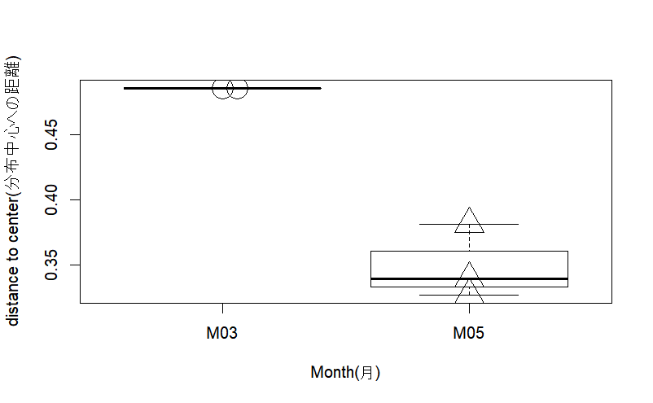

```r
#Visualization
boxplot(
  ryuko_BC_var$distances ~ phyto_metadata$month[c(1,2,13,14,15)], #3月と5月のデータのみ使用
  outline = FALSE,
  col = "white",
  xlab = "Month(月)", ylab = "distance to center(分布中心への距離)"
)
stripchart(
  ryuko_BC_var$distances ~ phyto_metadata$month[c(1,2,13,14,15)],
  method = "stack",
  pch = c(1,2),
  cex = 3,
  vertical = TRUE,
  add = TRUE
)
```

### 9.2 一般線形モデルの多変量への拡張２：回帰分析的状況

#### 9.2.2 冗長性分析（RDA）のためのＲコーディング

植物プランクトンデータに対する冗長性分析

```r
####RDA for phytoplankton
#説明要因はメタデータから持ってくる。温度・総個体数・種数
phyto.rda <- rda(species_ryuko_data ~ phyto_metadata$temp + total_abundance + species_richness)
#結果の表示
summary(phyto.rda)
```

```
Call:
rda(formula = species_ryuko_data ~ phyto_metadata$temp + total_abundance +      species_richness)

Partitioning of variance:
              Inertia Proportion
Total           32768     1.0000
Constrained     17548     0.5355
Unconstrained   15220     0.4645

Eigenvalues, and their contribution to the variance

Importance of components:
                           RDA1      RDA2      RDA3
Eigenvalue            1.511e+04 2.202e+03 2.378e+02
Proportion Explained  4.611e-01 6.721e-02 7.256e-03
Cumulative Proportion 4.611e-01 5.283e-01 5.355e-01
                            PC1       PC2       PC3
Eigenvalue            1.229e+04 1.444e+03 373.27542
Proportion Explained  3.752e-01 4.406e-02   0.01139
Cumulative Proportion 9.107e-01 9.548e-01   0.96617
                            PC4       PC5       PC6
Eigenvalue            3.214e+02 2.185e+02 1.693e+02
Proportion Explained  9.809e-03 6.669e-03 5.166e-03
Cumulative Proportion 9.760e-01 9.826e-01 9.878e-01
                            PC7       PC8       PC9
Eigenvalue            1.438e+02 1.175e+02 77.376067
Proportion Explained  4.387e-03 3.586e-03  0.002361
Cumulative Proportion 9.922e-01 9.958e-01  0.998145
                           PC10      PC11
Eigenvalue            34.692727 2.609e+01
Proportion Explained   0.001059 7.962e-04
Cumulative Proportion  0.999204 1.000e+00

Accumulated constrained eigenvalues
Importance of components:
                           RDA1      RDA2      RDA3
Eigenvalue            15108.403 2202.2966 237.75500
Proportion Explained      0.861    0.1255   0.01355
Cumulative Proportion     0.861    0.9865   1.00000

```

[output cut: 791 more lines]

```
20190520_1_ryuko.csv   0.7326   3.30687  10.637
20190520_2_ryuko.csv   1.9744   4.30560  -1.107
20190520_3_ryuko.csv   1.9080   0.08264   1.207


Biplot scores for constraining variables

                      RDA1     RDA2    RDA3 PC1 PC2
phyto_metadata$temp 0.8964  0.37467 -0.2368   0   0
total_abundance     0.9551 -0.27141 -0.1189   0   0
species_richness    0.5440  0.04071 -0.8381   0   0
                    PC3
phyto_metadata$temp   0
total_abundance       0
species_richness      0
```

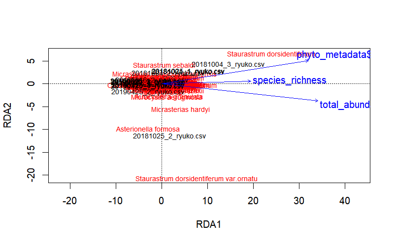

```r
#可視化：スケーリング１
plot(phyto.rda, scaling = 1, type = "text")
```

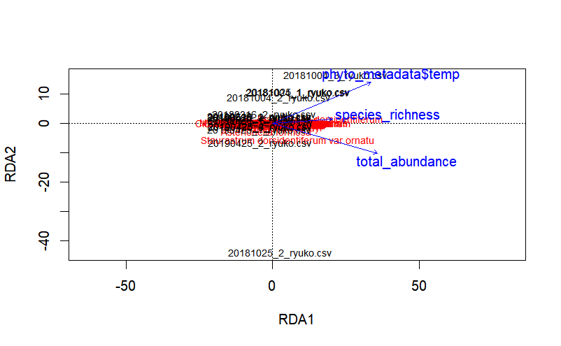

```r
#可視化：スケーリング２
plot(phyto.rda, scaling = 2, type = "text")
```

冗長性解析に対するランダム並び替え検定

```r
permutest(phyto.rda, by = "terms", perm = 1999)
```

```
Permutation test for rda under reduced model

Permutation: free
Number of permutations: 1999

Model: rda(formula = species_ryuko_data ~
phyto_metadata$temp + total_abundance +
species_richness)
Permutation test for sequential contrasts
                    Df Inertia      F Pr(>F)
phyto_metadata$temp  1 12463.0 9.0075 0.0015 **
total_abundance      1  4320.9 3.1229 0.0585 .
species_richness     1   764.6 0.5526 0.5985
Residual            11 15219.9
---
Signif. codes:
0 ‘***’ 0.001 ‘**’ 0.01 ‘*’ 0.05 ‘.’ 0.1 ‘ ’ 1
```

#### 9.2.4 CAP/dbRDAのためのRコーディング

CAP-capscale()とdbRDA-dbrda()の比較

```r
####CAP/dbRDA for phytoplankton####
#まずは共通部分 ブレイ・カーティス距離を計算
ryuko_BC.d <- vegdist(species_ryuko_data, method = "bray") #Bray-Curtis
#メタデータ中の温度情報を新しいオブジェクトtemperatureに格納
temperature <- phyto_metadata$temp

#CAPを使う場合
ryuko_CAP <- capscale(ryuko_BC.d ~ temperature + total_abundance + species_richness)
#dbRDAを使う場合
ryuko_dbRDA <- dbrda(ryuko_BC.d ~ temperature + total_abundance + species_richness)
```

```r
#CAPの結果
summary(ryuko_CAP)
```

```
Call:
capscale(formula = ryuko_BC.d ~ temperature + total_abundance +      species_richness)

Partitioning of squared Bray distance:
              Inertia Proportion
Total           4.626     1.0000
Constrained     1.604     0.3469
Unconstrained   3.021     0.6531

Eigenvalues, and their contribution to the squared Bray distance

Importance of components:
                        CAP1    CAP2    CAP3   MDS1
Eigenvalue            0.9839 0.40136 0.21917 0.6525
Proportion Explained  0.2127 0.08677 0.04738 0.1411
Cumulative Proportion 0.2127 0.29947 0.34685 0.4879
                        MDS2    MDS3    MDS4    MDS5
Eigenvalue            0.6098 0.41834 0.38170 0.23093
Proportion Explained  0.1318 0.09044 0.08252 0.04992
Cumulative Proportion 0.6197 0.71018 0.79269 0.84261
                         MDS6    MDS7    MDS8    MDS9
Eigenvalue            0.18784 0.14099 0.13098 0.11754
Proportion Explained  0.04061 0.03048 0.02831 0.02541
Cumulative Proportion 0.88322 0.91370 0.94202 0.96743
                        MDS10   MDS11
Eigenvalue            0.08431 0.06637
Proportion Explained  0.01823 0.01435
Cumulative Proportion 0.98565 1.00000

Accumulated constrained eigenvalues
Importance of components:
                        CAP1   CAP2   CAP3
Eigenvalue            0.9839 0.4014 0.2192
Proportion Explained  0.6132 0.2502 0.1366
Cumulative Proportion 0.6132 0.8634 1.0000

Scaling 2 for species and site scores
* Species are scaled proportional to eigenvalues
* Sites are unscaled: weighted dispersion equal on all dimensions
* General scaling constant of scores:  2.836793
```

[output cut: 88 more lines]

```
20190520_1_ryuko.csv  0.5551 -0.03825  0.5356
20190520_2_ryuko.csv  0.9618 -0.18238  0.5996
20190520_3_ryuko.csv  1.0395 -0.35538  0.1882


Biplot scores for constraining variables

                   CAP1    CAP2     CAP3 MDS1 MDS2
temperature      0.9587 -0.0339 -0.28232    0    0
total_abundance  0.8121  0.5775 -0.08382    0    0
species_richness 0.4936  0.2376 -0.83663    0    0
                 MDS3
temperature         0
total_abundance     0
species_richness    0
```

```r
#dbRDAの結果
summary(ryuko_dbRDA)
```

```
Call:
dbrda(formula = ryuko_BC.d ~ temperature + total_abundance +      species_richness)

Partitioning of squared Bray distance:
              Inertia Proportion
Total           4.626     1.0000
Constrained     1.604     0.3469
Unconstrained   3.021     0.6531

Eigenvalues, and their contribution to the squared Bray distance

Importance of components:
                      dbRDA1  dbRDA2  dbRDA3   MDS1
Eigenvalue            0.9839 0.40136 0.21917 0.6525
Proportion Explained  0.2127 0.08677 0.04738 0.1411
Cumulative Proportion 0.2127 0.29947 0.34685 0.4879
                        MDS2    MDS3    MDS4    MDS5
Eigenvalue            0.6098 0.41834 0.38170 0.23093
Proportion Explained  0.1318 0.09044 0.08252 0.04992
Cumulative Proportion 0.6197 0.71018 0.79269 0.84261
                         MDS6    MDS7    MDS8    MDS9
Eigenvalue            0.18784 0.14099 0.13098 0.11754
Proportion Explained  0.04061 0.03048 0.02831 0.02541
Cumulative Proportion 0.88322 0.91370 0.94202 0.96743
                        MDS10   MDS11
Eigenvalue            0.08431 0.06637
Proportion Explained  0.01823 0.01435
Cumulative Proportion 0.98565 1.00000

Accumulated constrained eigenvalues
Importance of components:
                      dbRDA1 dbRDA2 dbRDA3
Eigenvalue            0.9839 0.4014 0.2192
Proportion Explained  0.6132 0.2502 0.1366
Cumulative Proportion 0.6132 0.8634 1.0000

Scaling 2 for species and site scores
* Species are scaled proportional to eigenvalues
* Sites are unscaled: weighted dispersion equal on all dimensions
* General scaling constant of scores:  2.836793
```

[output cut: 69 more lines]

[output not shown]

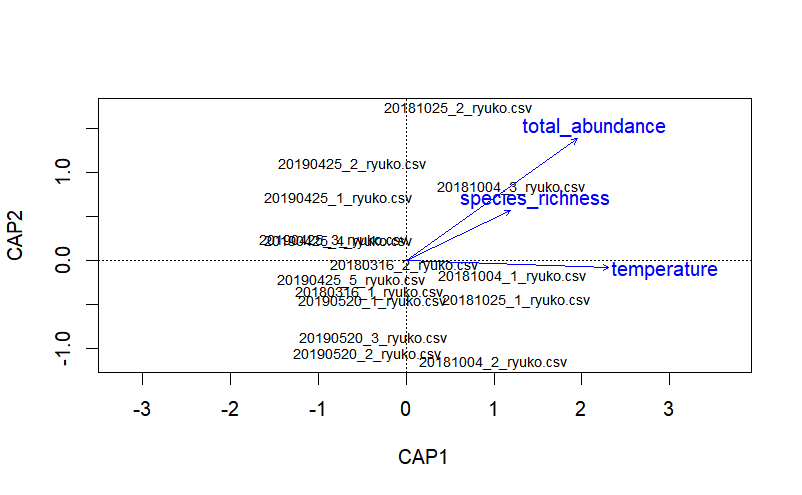

```r
#CAPの結果の可視化
plot(ryuko_CAP, scaling = 2, type = "text")
```

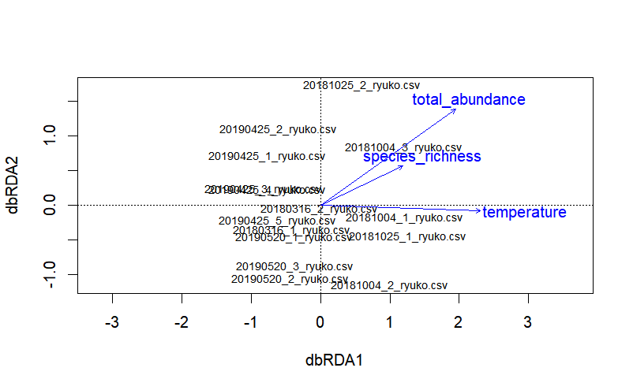

```r
#dbRDAの結果の可視化
plot(ryuko_dbRDA, scaling = 2, type = "text")
```

```r
#CAPの結果についてのランダム並び替え検定
permutest(ryuko_CAP, by = "terms", perm = 1999)
```

```
Permutation test for capscale under reduced model

Permutation: free
Number of permutations: 1999

Model: capscale(formula = ryuko_BC.d ~
temperature + total_abundance +
species_richness)
Permutation test for sequential contrasts
                 Df Inertia      F Pr(>F)
temperature       1 0.92230 3.3579 0.0005 ***
total_abundance   1 0.39825 1.4499 0.1105
species_richness  1 0.28391 1.0336 0.4195
Residual         11 3.02130
---
Signif. codes:
0 ‘***’ 0.001 ‘**’ 0.01 ‘*’ 0.05 ‘.’ 0.1 ‘ ’ 1
```

```r
#dbRDAの結果についてのランダム並び替え検定
permutest(ryuko_dbRDA, by = "terms", perm = 1999)
```

```
Permutation test for dbrda under reduced model

Permutation: free
Number of permutations: 1999

Model: dbrda(formula = ryuko_BC.d ~ temperature
+ total_abundance + species_richness)
Permutation test for sequential contrasts
                 Df Inertia      F Pr(>F)
temperature       1 0.92230 3.3579 0.0005 ***
total_abundance   1 0.39825 1.4499 0.1130
species_richness  1 0.28391 1.0336 0.4150
Residual         11 3.02130
---
Signif. codes:
0 ‘***’ 0.001 ‘**’ 0.01 ‘*’ 0.05 ‘.’ 0.1 ‘ ’ 1
```

#### 9.2.5 カテゴリー変数と量的変数も混ぜて使うことが可能

```r
#月情報をメタデータから抜き出して新しいオブジェクトmonthに格納
month <- phyto_metadata$month
#capscaleをつかってCAPを実行
ryuko_CAP2 <- capscale(ryuko_BC.d ~ temperature + total_abundance + species_richness + month)
#ランダム並び替え検定
permutest(ryuko_CAP2, by = "terms", perm = 1999)
```

```
Permutation test for capscale under reduced model

Permutation: free
Number of permutations: 1999

Model: capscale(formula = ryuko_BC.d ~
temperature + total_abundance +
species_richness + month)
Permutation test for sequential contrasts
                 Df Inertia      F Pr(>F)
temperature       1 0.92230 4.2185 0.0005 ***
total_abundance   1 0.39825 1.8215 0.0280 *
species_richness  1 0.28391 1.2986 0.2010
month             3 1.27225 1.9397 0.0025 **
Residual          8 1.74905
---
Signif. codes:
0 ‘***’ 0.001 ‘**’ 0.01 ‘*’ 0.05 ‘.’ 0.1 ‘ ’ 1
```

### BOX9 adonis()/capscale()/dbrda()の違い

ジャッカード距離で月間比較

```r
####PERMANOVA, CAP, and dbRDA####
#距離行列の計算
ryuko_J.d <- vegdist(species_ryuko_data, method = "jaccard", binary = TRUE) #jaccard
#PERMANOVAによる検定
adonis(ryuko_J.d  ~ month)$aov.tab
```

```
'adonis' will be deprecated: use 'adonis2' instead
```

```
Permutation: free
Number of permutations: 999

Terms added sequentially (first to last)

          Df SumsOfSqs MeanSqs F.Model      R2 Pr(>F)
month      3    1.3581 0.45269  1.6785 0.31402  0.001
Residuals 11    2.9667 0.26970         0.68598
Total     14    4.3248                 1.00000

month     ***
Residuals
Total
---
Signif. codes:
0 ‘***’ 0.001 ‘**’ 0.01 ‘*’ 0.05 ‘.’ 0.1 ‘ ’ 1
```

```r
#capscaleに対するランダム並び替え検定
permutest(capscale(ryuko_J.d ~ month), by = "terms", perm = 999)
```

```
Permutation test for capscale under reduced model

Permutation: free
Number of permutations: 999

Model: capscale(formula = ryuko_J.d ~ month)
Permutation test for all constrained eigenvalues
         Df Inertia      F Pr(>F)
month     3  1.3581 1.6785  0.001 ***
Residual 11  2.9667
---
Signif. codes:
0 ‘***’ 0.001 ‘**’ 0.01 ‘*’ 0.05 ‘.’ 0.1 ‘ ’ 1
```

```r
#dbrdaに対するランダム並び替え検定
permutest(dbrda(ryuko_J.d ~ month), by = "terms", perm = 999)
```

```
Permutation test for dbrda under reduced model

Permutation: free
Number of permutations: 999

Model: dbrda(formula = ryuko_J.d ~ month)
Permutation test for all constrained eigenvalues
         Df Inertia      F Pr(>F)
month     3  1.3581 1.6785  0.001 ***
Residual 11  2.9667
---
Signif. codes:
0 ‘***’ 0.001 ‘**’ 0.01 ‘*’ 0.05 ‘.’ 0.1 ‘ ’ 1
```